# Protecting Lives Early: HepB3 Vaccination Around the World

*Every child deserves protection from a preventable disease.*

Author

Dimitra Kalampoka

Published

April 14, 2026

Hepatitis B can be stopped with *three vaccine doses* given early in life, a core commitment under United Nations Sustainable Development Goal 3. HepB3 vaccination coverage shows where children are protected, where gaps remain and how close the world is to the **WHO goal** of at least *90% coverage* for every country.

**Note*WHO classification according to vaccination coverage:**

- Urgent action required (<70%)
- Action needed (70-79%)
- Acceptable but below target (80-89%)
- Within target (>90%)

```python
from google.colab import drive
drive.mount("/content/drive")
```

```python
import polars as pl
from plotnine import *

unicef_indicator2=pl.read_csv('/content/drive/MyDrive/unicef_indicator_2.csv')
unicef_metadata=pl.read_csv('/content/drive/MyDrive/unicef_metadata.csv')
```

```python
unicef_metadata.head() #check that data frame column names and values are correct
```

```python
unicef_indicator2 = unicef_indicator2.rename({"time_period":"year"}) #renaming column to facilitate join in next steps
unicef_indicator2.head() #check that data frame column names and values are correct
```

```python
joined_data =  unicef_indicator2.join(unicef_metadata, on=['numeric_code','year'], how = "full") #joined the data frames into a new data frame
joined_data = joined_data.rename({"obs_value":"HepB3_vaccination(%)"}) #renamed column to facilitate analysis
joined_data.head() #check that data frame column names and values are correct
```

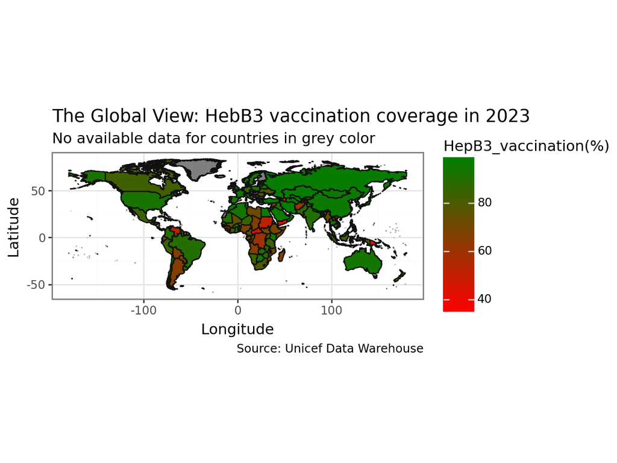

```python
import geopandas as gp

shape_world = gp.read_file("https://public.opendatasoft.com/api/explore/v2.1/catalog/datasets/world-administrative-boundaries/exports/shp")

country_code = pl.read_csv("https://raw.githubusercontent.com/adrivsh/country_names/refs/heads/master/names_to_iso.csv")
joined_data_code = (joined_data.join(country_code, on="country", how="left"))
joined_data_code_2023 = (joined_data_code.filter(pl.col("year") == 2023))
shape_joined_data_code_2023 = (shape_world
  .merge(joined_data_code_2023.to_pandas(), on="iso3", how="outer")
)

(ggplot(data=shape_joined_data_code_2023)
  + aes(fill="HepB3_vaccination(%)")
  + geom_map()
  + scale_fill_gradient(low="red", high="green")
  + labs(
      title="The Global View: HebB3 vaccination coverage in 2023",
      subtitle="No available data for countries in grey color",
      caption="Source: Unicef Data Warehouse",
      x="Longitude",
      y="Latitude",
      fill="HepB3_vaccination(%)"
  )
  + coord_fixed()
  + theme_bw()
)
```

**Important*What the global overview reveals**

According to the latest available data (2023), the map highlights *Africa* and *South America* as the regions with the highest concentration of countries requiring immediate action under the WHO classification.

### Let’s take a closer look: which *5 countries* had the *lowest HepB3 vaccination coverage* in 2023?

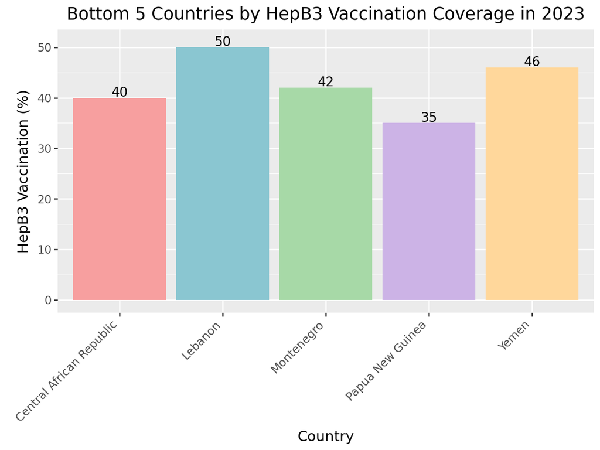

```python
#define a consistent color mapping for the 5 countries across the report
country_colors = {
    "Central African Republic": "#F79F9F",
    "Lebanon": "#8AC6D1",
    "Montenegro": "#A7D9A7",
    "Papua New Guinea": "#CCB3E6",
    "Yemen": "#FFD79B"
}

(joined_data
  .filter(pl.col("year") == 2023)
  .sort("HepB3_vaccination(%)")
  .head(5)
  >>
  ggplot(aes(x="country", y="HepB3_vaccination(%)", fill="country"))
  + geom_col()
  + geom_text(aes(label="HepB3_vaccination(%)"), nudge_y=1, size=10) #add data labels
  + scale_fill_manual(values=country_colors) #use manual color mapping
  + labs(
      title="Bottom 5 Countries by HepB3 Vaccination Coverage in 2023",
      x="Country",
      y="HepB3 Vaccination (%)"
    )
  + theme(axis_text_x=element_text(rotation=45, hjust=1))
  + guides(fill="none")
)
```

### In these countries, how has *HepB3 vaccination rate* evolved *over time*?

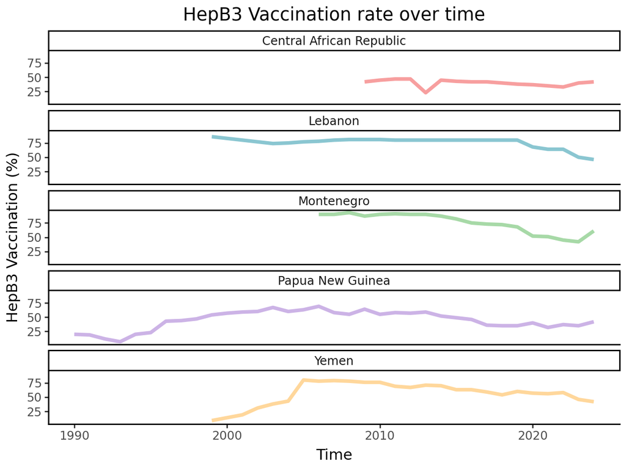

```python
bottom5_2023_pl = (joined_data
  .filter(pl.col("country").is_in(["Central African Republic", "Lebanon", "Montenegro", "Papua New Guinea", "Yemen"]))) #focusing on the 5 countries only

(ggplot(bottom5_2023_pl)
+ aes(x="year", y="HepB3_vaccination(%)", color="country")
+ geom_line(size=1.5)
+ scale_color_manual(values=country_colors) #use manual color mapping
+ facet_wrap("country", nrow=5)
+ labs(
      title="HepB3 Vaccination rate over time",
      x="Time",
      y="HepB3 Vaccination (%)"
    )
+ theme_classic()
+ guides(color="none")
)
```

### What about *Life expectancy at birth* ?

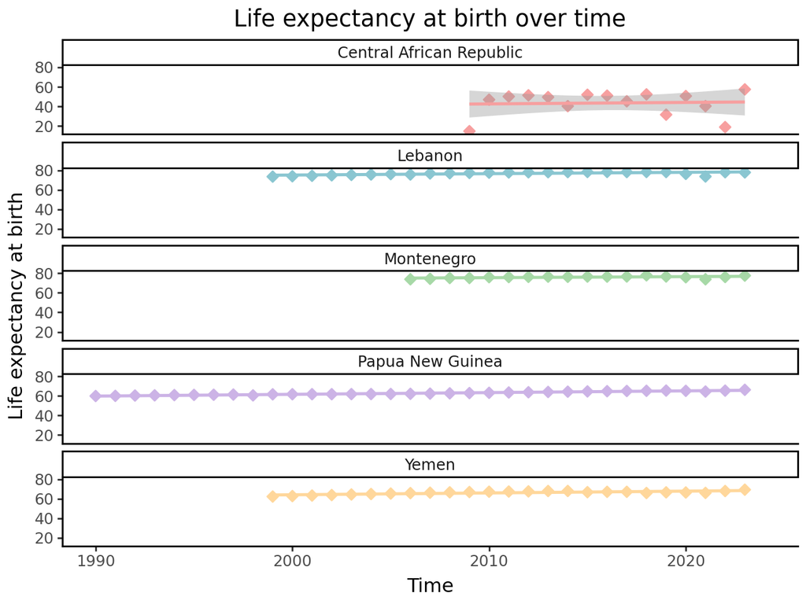

```python
(ggplot(bottom5_2023_pl)
+ aes(x="year", y="Life expectancy at birth, total (years)",color="country")
+ geom_point(size=2, shape='D') #add size and shape parameters
+ geom_smooth(method="lm")
+ scale_color_manual(values=country_colors) #use manual color mapping
+ facet_wrap("country", nrow=5)
+ labs(
      title="Life expectancy at birth over time",
      x="Time",
      y="Life expectancy at birth"
      )
+ theme_classic()
+ guides(color="none")
)
```

### For those countries, is vaccination coverage related to *income level*?

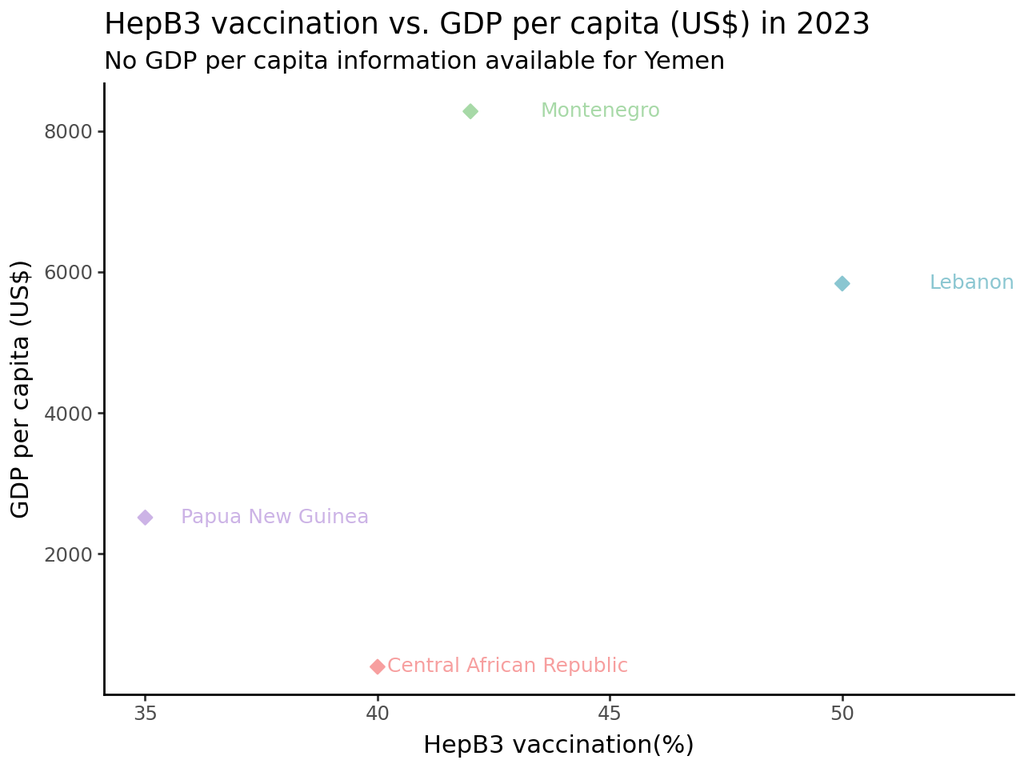

```python
(joined_data
  .filter(pl.col("year") == 2023)
  .sort("HepB3_vaccination(%)")
  .head(5)
  >>
 (ggplot(aes(x="HepB3_vaccination(%)", y="GDP per capita (constant 2015 US$)", color="country"))
  + geom_point(size=2, shape='D')
  + geom_text(aes(label="country"), nudge_x=2.8, nudge_y=0.8, size=9) # Added data labels for country names
  + scale_color_manual(values=country_colors) # Use manual colors
  + labs(
      title="HepB3 vaccination vs. GDP per capita (US$) in 2023",
      subtitle="No GDP per capita information available for Yemen",
      x="HepB3 vaccination(%)",
      y="GDP per capita (US$)"
      )
  + theme_classic()
  + guides(color="none") #removed unnecessary legend as labels are added
))
```

**Tip*Five* countries. *Immediate* action. **THE TIME TO ACT IS** *NOW.**

*Learn more about how you can help at :* https://www.unicef.org/

*Data Source :* [Unicef Data Warehouse](https://data.unicef.org/dv_index/)

[figure not shown]

unicef.png

```python
!quarto render "/content/drive/MyDrive/Colab Notebooks/report.ipynb"
```